# Final Presentation

Gabe, Oonagh, Bao, Yukari

2023-03-11

## Loading Libraries

```r
library(tidyverse)
library(janitor)
library(shiny)
library(shinydashboard)
```

```r
library(ggplot2)
library(naniar)
library(lubridate)
library(dplyr)
library(RColorBrewer)
library(paletteer)
library(readr)
library(ggmap)
library(devtools)
library(here)
library(ggrepel)
```

## Loading & Cleaning Data

```r
visibility <- read_csv("data/CA_visibility_data.csv")
visibility_tidy <- visibility%>%
  na_if(-999)
```

## Generating Maps (Oonagh)

**Step 1: Create a Base Map**

1. Find the range of latitude and longitude for our data:

```r
visibility_tidy %>%
  select(Latitude, Longitude) %>% #note that the lat and long are in degrees decimal
  summary()
```

```
##     Latitude       Longitude
##  Min.   :33.46   Min.   :-124.1
##  1st Qu.:34.73   1st Qu.:-121.2
##  Median :37.22   Median :-119.7
##  Mean   :37.32   Mean   :-119.7
##  3rd Qu.:38.98   3rd Qu.:-118.1
##  Max.   :41.71   Max.   :-116.4
```

2. Set the bounding box range:

```r
lat <- c(33.46, 41.71)
long <- c(-124.1, -116.4)
bbox <- make_bbox(long, lat, f = 0.05)
```

3. Generate the bounding box

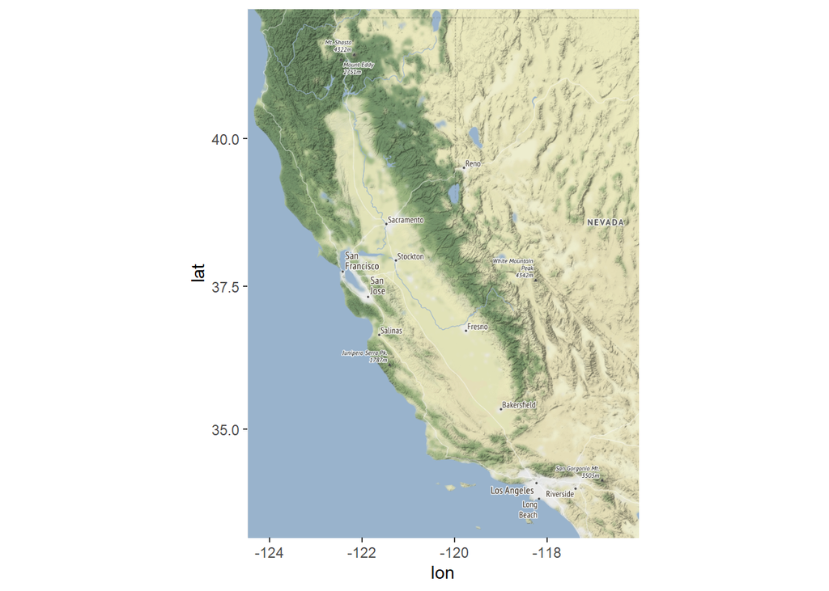

```r
map1 <- get_map(bbox, maptype = "terrain", source = "stamen")
ggmap(map1)
```

**Step 2: Adding Points to Base Map**

*I. Basic map with site locations*

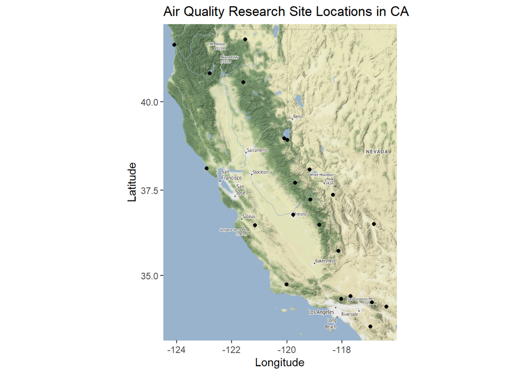

```r
ggmap(map1) +
  geom_point(data = visibility_tidy, aes(Longitude, Latitude), size=1.5) +
  labs(x= "Longitude", y= "Latitude", title="Air Quality Research Site Locations in CA")
```

```r
  #ggsave("plot.png", width = 5, height = 5)
```

*II.Basic map with site location and by elevation*

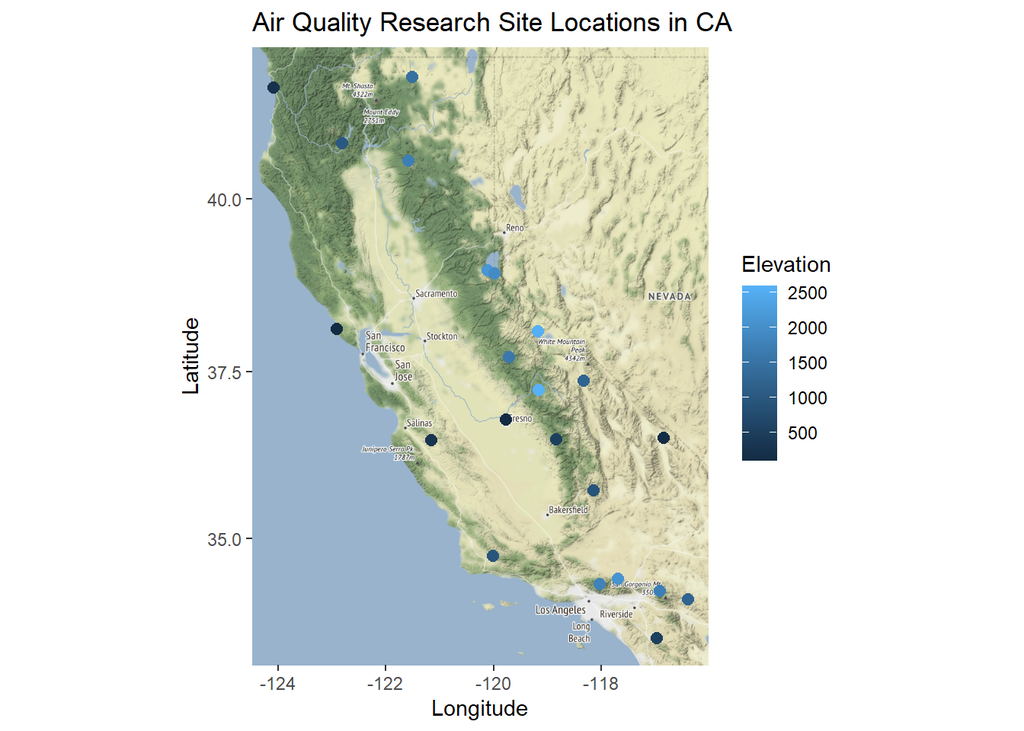

```r
ggmap(map1) +
  geom_point(data = visibility_tidy, aes(Longitude, Latitude, colour=Elevation), size=2.5) +
  labs(x= "Longitude", y= "Latitude", title="Air Quality Research Site Locations in CA")
```

*III.Basic map with site location and colour name key* - not informative

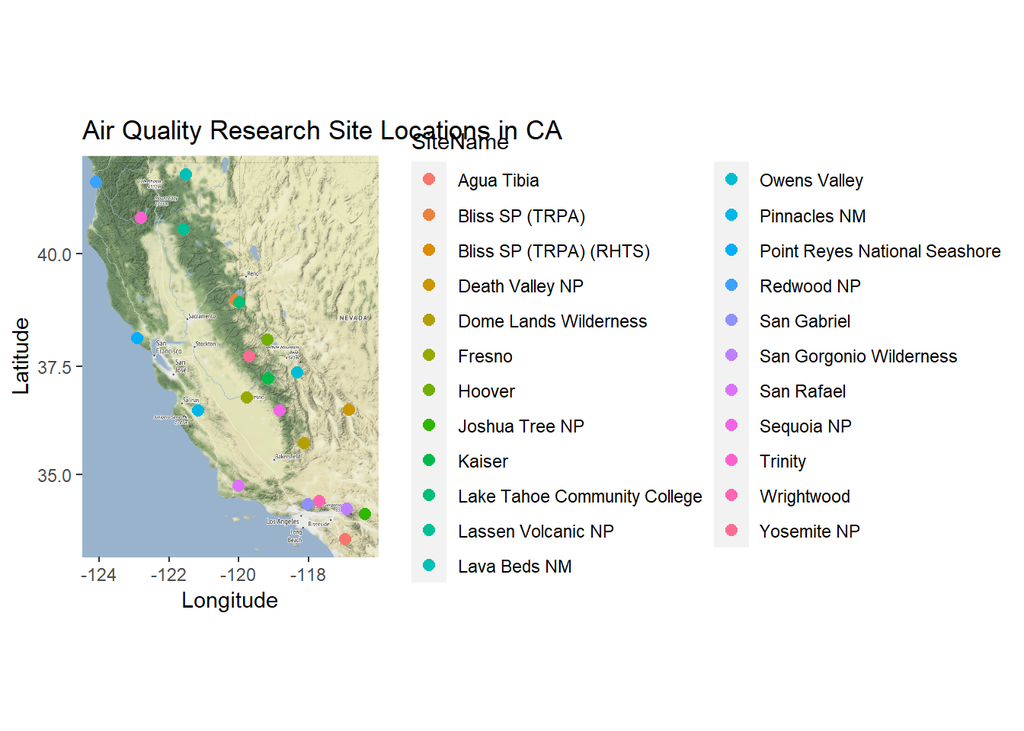

```r
ggmap(map1) +
  geom_point(data = visibility_tidy, aes(Longitude, Latitude, colour=SiteName), size=2.5) +
  labs(x= "Longitude", y= "Latitude", title="Air Quality Research Site Locations in CA")
```

*IV.Basic map with only ONE site location* - not informative

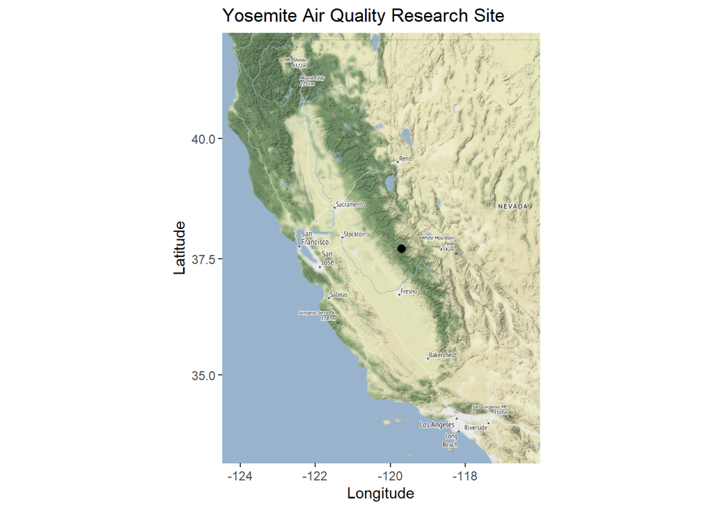

```r
visibility_yos <- visibility_tidy %>%
  filter(SiteName=="Yosemite NP")

  ggmap(map1) +
  geom_point(data = visibility_yos, aes(Longitude, Latitude), size=2.5) +
  labs(x= "Longitude", y= "Latitude", title="Yosemite Air Quality Research Site")
```

**Saving maps**

```r
ggsave("plot.png", width = 5, height = 5) #Saves last plot as 5’ x 5’ file named "plot.png" in working directory.
#Matches file type to file extension.
```

Split date by year:

```r
visibility2 <- visibility_tidy %>%
  separate(Date, into= c("month", "day", "year"), sep = "/")
```

```r
visibility3 <- visibility2 %>%
  group_by(SiteName, year) %>%
  summarise(across(c(SVR_Val, ammNO3f_Val, ammSO4f_Val, ECf_Val, OMCf_Val, SOILf_Val, Longitude, Latitude), mean, na.rm=T), total=n())
```

**A) Graph Mean Standard Visual Range over time, faceted by site**

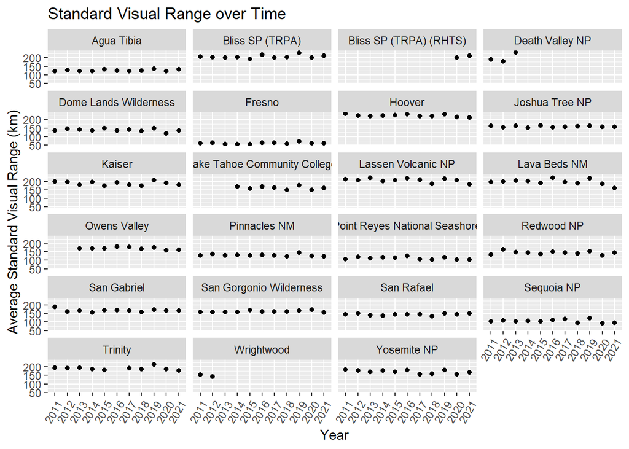

```r
visibility3 %>%
  ggplot(aes(x=year, y=SVR_Val))+
  geom_point(na.rm=TRUE)+
  facet_wrap(~SiteName, ncol=4)+
  theme(axis.text.x = element_text(angle = 60, hjust = 1))+
  labs(title = "Standard Visual Range over Time",
       x = "Year",
       y = "Average Standard Visual Range (km)",) #fill by season?
```

**B) Graph Mean Ammonium Nitrate Concentration Over Time** faceted by site

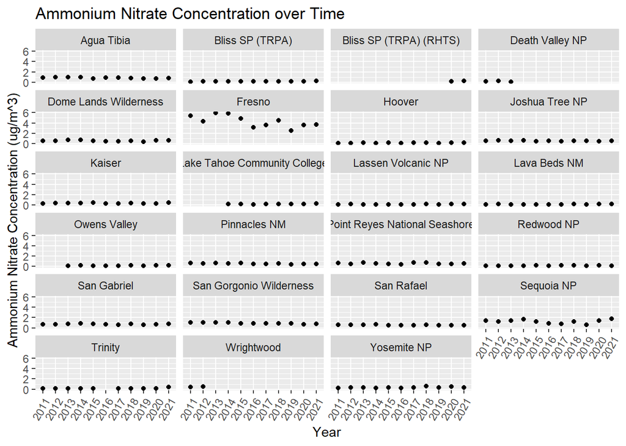

```r
visibility3 %>%
  ggplot(aes(x=year, y=ammNO3f_Val))+
  geom_point(na.rm=TRUE)+
  facet_wrap(~SiteName, ncol=4)+
  theme(axis.text.x = element_text(angle = 60, hjust = 1))+
  labs(title = "Ammonium Nitrate Concentration over Time",
       x = "Year",
       y = "Ammonium Nitrate Concentration (ug/m^3)",) #fill by season?
```

**C) Graph Mean Ammonium Sulfate Concentration Over Time** faceted by site

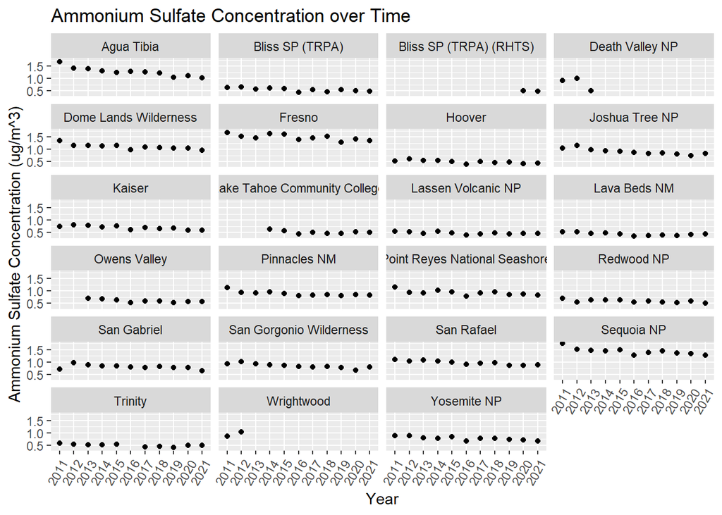

```r
visibility3 %>%
  ggplot(aes(x=year, y=ammSO4f_Val))+
  geom_point(na.rm=TRUE)+
  facet_wrap(~SiteName, ncol=4)+
  theme(axis.text.x = element_text(angle = 60, hjust = 1))+
  labs(title = "Ammonium Sulfate Concentration over Time",
       x = "Year",
       y = "Ammonium Sulfate Concentration (ug/m^3)",) #fill by season?
```

**D) Graph Mean Elemental Carbon Concentration Over Time** faceted by site

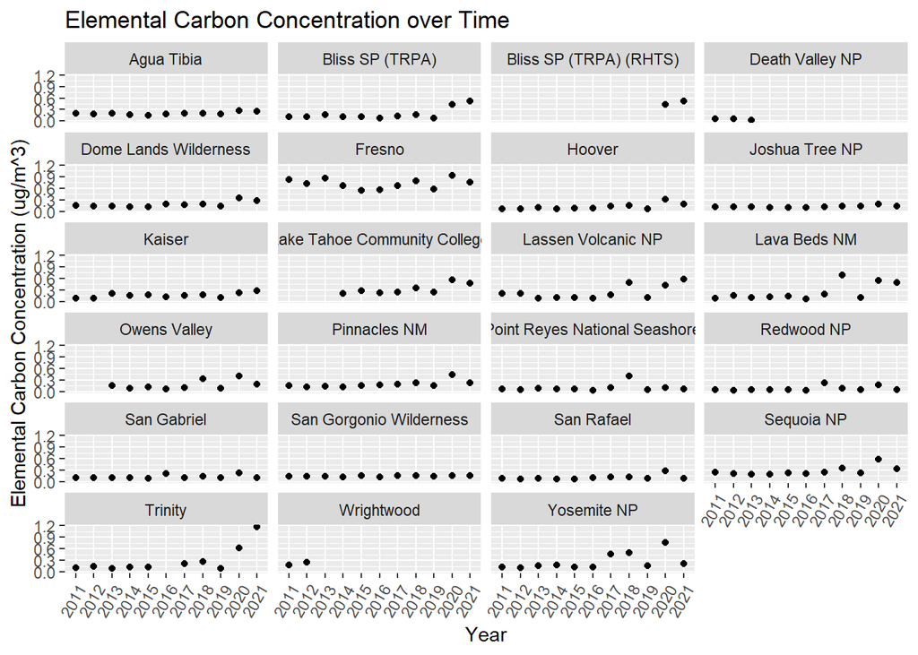

```r
visibility3 %>%
  ggplot(aes(x=year, y=ECf_Val))+
  geom_point(na.rm=TRUE)+
  facet_wrap(~SiteName, ncol=4)+
  theme(axis.text.x = element_text(angle = 60, hjust = 1))+
  labs(title = "Elemental Carbon Concentration over Time",
       x = "Year",
       y = "Elemental Carbon Concentration (ug/m^3)",) #fill by season?
```

*Notes: Interesting fluctuations for Lassen, Lava Beds, Point Reyes, Yosemite, Sequoia, Trinity. Link to wildfire data?*

## Generating Wildfire Graphs (Yukari)

**Separate Dates for plotting**

```r
visibility_mdy <- visibility_tidy%>%
  separate(Date, into = c("month", "day", "year"))
visibility_mdy
```

```
## # A tibble: 26,633 × 24
##    Dataset SiteCode   POC month day   year  Percentile SiteName  Latit…¹ Longi…²
##    <chr>   <chr>    <dbl> <chr> <chr> <chr>      <dbl> <chr>       <dbl>   <dbl>
##  1 IMPRHR2 AGTI1        1 1     3     2011          10 Agua Tib…    33.5   -117.
##  2 IMPRHR2 AGTI1        1 1     6     2011          10 Agua Tib…    33.5   -117.
##  3 IMPRHR2 AGTI1        1 1     9     2011          70 Agua Tib…    33.5   -117.
##  4 IMPRHR2 AGTI1        1 1     12    2011          10 Agua Tib…    33.5   -117.
##  5 IMPRHR2 AGTI1        1 1     15    2011          10 Agua Tib…    33.5   -117.
##  6 IMPRHR2 AGTI1        1 1     18    2011          10 Agua Tib…    33.5   -117.
##  7 IMPRHR2 AGTI1        1 1     21    2011          10 Agua Tib…    33.5   -117.
##  8 IMPRHR2 AGTI1        1 1     24    2011          10 Agua Tib…    33.5   -117.
##  9 IMPRHR2 AGTI1        1 1     27    2011          10 Agua Tib…    33.5   -117.
## 10 IMPRHR2 AGTI1        1 1     30    2011          50 Agua Tib…    33.5   -117.
## # … with 26,623 more rows, 14 more variables: Elevation <dbl>, State <chr>,
## #   ammNO3f_Val <dbl>, ammNO3f_Unit <chr>, ammSO4f_Val <dbl>,
## #   ammSO4f_Unit <chr>, ECf_Val <dbl>, ECf_Unit <chr>, OMCf_Val <dbl>,
## #   OMCf_Unit <chr>, SOILf_Val <dbl>, SOILf_Unit <chr>, SVR_Val <dbl>,
## #   SVR_Unit <chr>, and abbreviated variable names ¹Latitude, ²Longitude
```

**Make Plots** Yosemite National Park - 2016 -> 2017 -> 2018 Empire Fire, Ferguson Fire

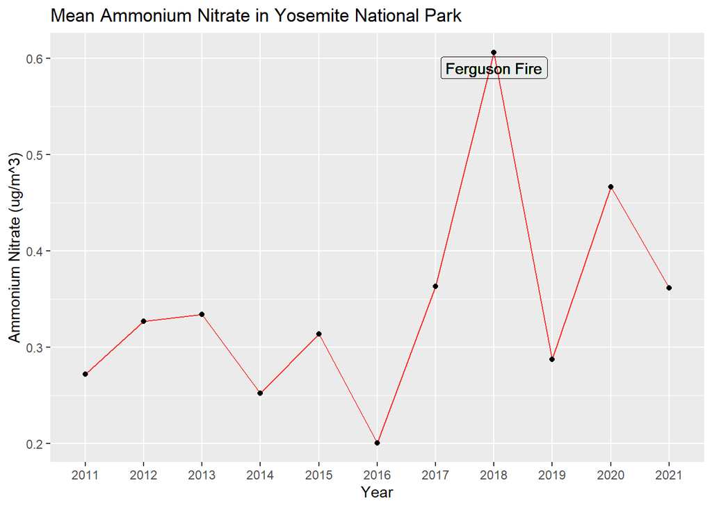

```r
visibility_mdy %>%
  group_by(SiteName, year) %>%
  filter(SiteName=="Yosemite NP") %>%
  summarize(mean_ano3_year= mean(ammNO3f_Val, na.rm = T)) %>%
  ggplot(aes(x=year, y=mean_ano3_year)) +
  geom_line(color="red",
            alpha = 0.8,
            group = 1) +
  geom_point() +
  geom_label(label = "Ferguson Fire",
            x = 8,
            y = .59,
            color = "black",
            fill = NA) +
  labs(title = "Mean Ammonium Nitrate in Yosemite National Park",
       x = "Year",
       y = "Ammonium Nitrate (ug/m^3)")
```

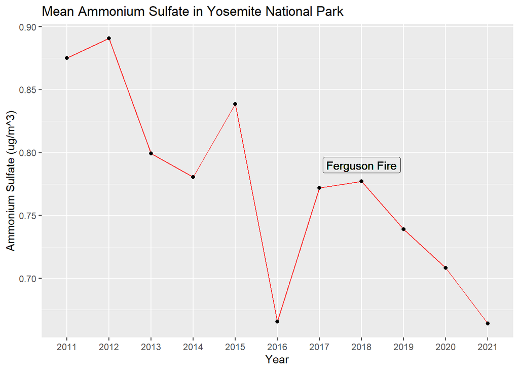

```r
ggsave("yosemitenp_ammno3.png",
       plot = last_plot())
visibility_mdy %>%
  group_by(SiteName, year) %>%
  filter(SiteName=="Yosemite NP") %>%
  summarize(mean_aso4_year= mean(ammSO4f_Val, na.rm = T)) %>%
  ggplot(aes(x=year, y=mean_aso4_year))+
  geom_line(color="red",
            alpha = 0.8,
            group = 1) +
  geom_point() +
  geom_label(label = "Ferguson Fire",
            x = 8,
            y = .79,
            color = "black",
            fill = NA) +
  labs(title = "Mean Ammonium Sulfate in Yosemite National Park",
       x = "Year",
       y = "Ammonium Sulfate (ug/m^3)")
```

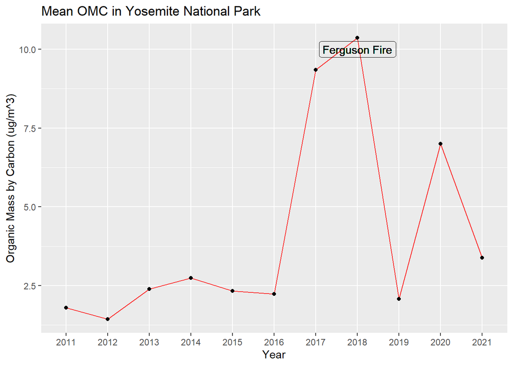

```r
ggsave("yosemitenp_ammso4.png",
       plot = last_plot())
visibility_mdy %>%
  group_by(SiteName, year) %>%
  filter(SiteName=="Yosemite NP") %>%
  summarize(mean_omc_year= mean(OMCf_Val, na.rm = T)) %>%
  ggplot(aes(x=year, y=mean_omc_year))+
  geom_line(color="red",
            alpha = 0.8,
            group = 1) +
  geom_point() +
  geom_label(label = "Ferguson Fire",
            x = 8,
            y = 10,
            color = "black",
            fill = NA) +
  labs(title = "Mean OMC in Yosemite National Park",
       x = "Year",
       y = "Organic Mass by Carbon (ug/m^3)")
```

```r
ggsave("yosemitenp_omc.png",
       plot = last_plot())
```

Lassen Volcanic National Park - 2020 -> 2021 Dixie Fire

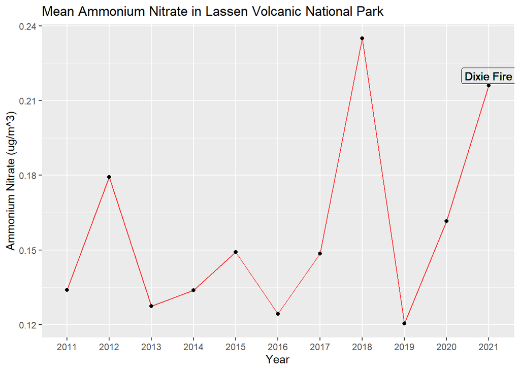

```r
visibility_mdy %>%
  group_by(SiteName, year) %>%
  filter(SiteName=="Lassen Volcanic NP") %>%
  summarize(mean_ano3_year= mean(ammNO3f_Val, na.rm = T)) %>%
  ggplot(aes(x=year, y=mean_ano3_year)) +
  geom_line(color="red",
            alpha = 0.8,
            group = 1) +
  geom_point() +
  geom_label(label = "Dixie Fire",
            x = 11,
            y = .22,
            color = "black",
            fill = NA) +
  labs(title = "Mean Ammonium Nitrate in Lassen Volcanic National Park",
       x = "Year",
       y = "Ammonium Nitrate (ug/m^3)")
```

```r
ggsave("lassenvolcanicnp_ammno3.png",
       plot = last_plot(),
       width = 7,
       height = 5)
```

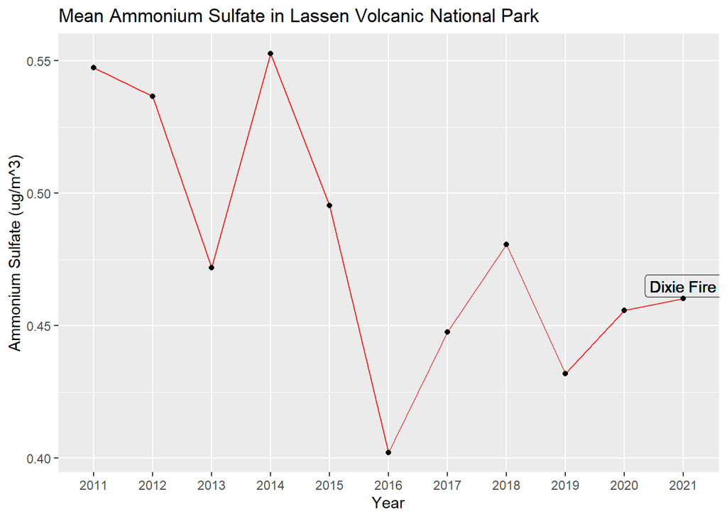

```r
visibility_mdy %>%
  group_by(SiteName, year) %>%
  filter(SiteName=="Lassen Volcanic NP") %>%
  summarize(mean_aso4_year= mean(ammSO4f_Val, na.rm = T)) %>%
  ggplot(aes(x=year, y=mean_aso4_year))+
  geom_line(color="red",
            alpha = 0.8,
            group = 1) +
  geom_point() +
  geom_label(label = "Dixie Fire",
            x = 11,
            y = .465,
            color = "black",
            fill = NA) +
  labs(title = "Mean Ammonium Sulfate in Lassen Volcanic National Park",
       x = "Year",
       y = "Ammonium Sulfate (ug/m^3)")
```

```r
ggsave("lassenvolcanicnp_ammso4.png",
       plot = last_plot(),
       width = 7,
       height = 5)
```

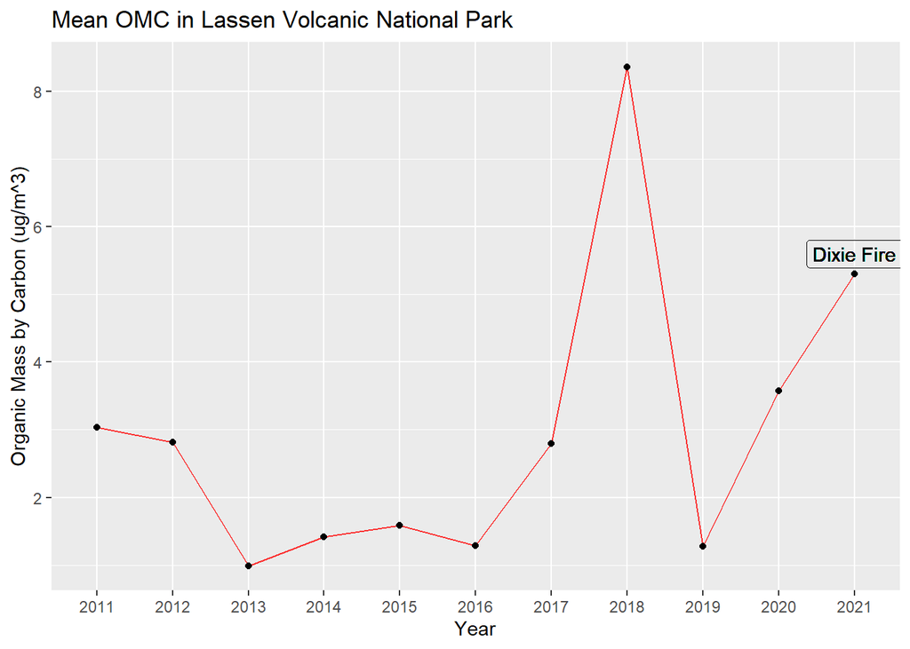

```r
visibility_mdy %>%
  group_by(SiteName, year) %>%
  filter(SiteName=="Lassen Volcanic NP") %>%
  summarize(mean_omc_year= mean(OMCf_Val, na.rm = T)) %>%
  ggplot(aes(x=year, y=mean_omc_year))+
  geom_line(color="red",
            alpha = 0.8,
            group = 1) +
  geom_point() +
  geom_label(label = "Dixie Fire",
            x = 11,
            y = 5.6,
            color = "black",
            fill = NA) +
  labs(title = "Mean OMC in Lassen Volcanic National Park",
       x = "Year",
       y = "Organic Mass by Carbon (ug/m^3)")
```

```r
ggsave("lassenvolcanicnp_omc.png",
       plot = last_plot(),
       width = 7,
       height = 5)
```

## Shiny App: Mean Standard Visual Range per Year by Site (Bao)

```r
improve_visibility <- visibility %>%
  clean_names() %>%
  na_if("-999") %>%
  select(date, site_name, state,svr_val) %>%
  separate(date, into = c("month", "day", "year"))
```

```r
ui <- dashboardPage(
  dashboardHeader(title = tags$div(style = "font-size: 30px;",
    "Visual Range CA")),
  dashboardSidebar(disable = TRUE),

  dashboardBody(
      tags$head(
      tags$style(HTML(".box{border-radius: 20px; box-shadow: 5px 5px 10px #888888;}"))),

  fluidRow( class="text center",
  box(title= "Plot Options",width = 2,
      radioButtons("x", "Choose The Site", choices = c("Agua Tibia", "Bliss SP (TRPA)", "Bliss SP (TRPA) (RHTS)", "Death Valley NP", "Dome Lands Wilderness", "Fresno", "Hoover", "Joshua Tree NP", "Kaiser", "Lake Tahoe Community College", "Lassen Volcanic NP", "Lava Beds NM", "Owens Valley", "Pinnacles NM", "Point Reyes National Seashore", "Redwood NP", "San Gabriel", "San Gorgonio Wilderness", "San Rafael", "Sequoia NP", "Trinity", "Wrightwood", "Yosemite NP")
)
),  #Close box

box(title = h2("Standard Visual Range Over the Year", align="center"), width = 6, align="center",solidHeader = T,
plotOutput("plot", width = "550px", height = "525px")),

box(title="", width = 4, height = 650,
imageOutput("image"), style ="text-align: center;"
),
) #close fluidrow
) #close dashboardbody
) #close dashboard page

server <- function(input, output, session) {
  session$onSessionEnded(stopApp)
  output$plot <- renderPlot({
  improve_visibility %>%
  group_by(site_name, year) %>%
  summarize("Mean_Standard_Visual_Range_km"= mean(svr_val, na.rm = T)) %>%
  filter(site_name==input$x) %>%
  ggplot(aes(x=year, y=Mean_Standard_Visual_Range_km,group=2, color=Mean_Standard_Visual_Range_km))+
  geom_line(size=1.5,alpha=0.8)+
  geom_point(size=5)+
      theme(axis.title.x = element_text(size = 23, margin = margin(t = 15)))+
      theme(axis.title.y = element_text(size = 23,  margin = margin(r = 20)))+
      theme(axis.text = element_text(size = 14))+
      labs(y = "Average Standard Visual Range (km)")+
      labs(x = "Year")+
      scale_color_gradient(low="blue", high="red")+
      guides(color = FALSE)
  })
  output$image <- renderImage({
    list(src = "map.png", height = "570px", width="450px")
  }, deleteFile = FALSE)

  }

shinyApp(ui, server, options = list(launch.browser = TRUE))
```

## Shiny App: Seasonal Metrics per Year by Site (Gabe)

**Designating Seasons** *Warning: This code block is not time efficient (O(n)), expect a long run time.*

```r
seasons <- c()

for (date in visibility_tidy$Date){
  date <- mdy(date)
  # Winter Dec 20 - Mar 19
  if ((month(date) == 12 & day(date) >= 20) | month(date) %in% c(1, 2) | (month(date) == 3 & day(date) <= 19)){
    seasons <- c(seasons, "winter")
  }
  # Spring Mar 20 - June 20
  else if ((month(date) == 3 & day(date) >= 20) | month(date) %in% c(4, 5) | (month(date) == 6 & day(date) <= 20)){
    seasons <- c(seasons, "spring")
  }
  # Summer June 21 - Sept 22
  else if ((month(date) == 6 & day(date) >= 21) | month(date) %in% c(7, 8) | (month(date) == 9 & day(date) <= 22)){
    seasons <- c(seasons, "summer")
  }
  # Autumn Sept 23 - Dec 19
  else{
    seasons <- c(seasons, "autumn")
  }
}

visibility_tidy$season = seasons
```

**Separate Dates for plotting**

```r
visibility_tidy_mdy <- visibility_tidy%>%
  separate(Date, into = c("month", "day", "year"))
head(visibility_tidy_mdy)
```

```
## # A tibble: 6 × 25
##   Dataset SiteCode   POC month day   year  Percentile SiteName   Latit…¹ Longi…²
##   <chr>   <chr>    <dbl> <chr> <chr> <chr>      <dbl> <chr>        <dbl>   <dbl>
## 1 IMPRHR2 AGTI1        1 1     3     2011          10 Agua Tibia    33.5   -117.
## 2 IMPRHR2 AGTI1        1 1     6     2011          10 Agua Tibia    33.5   -117.
## 3 IMPRHR2 AGTI1        1 1     9     2011          70 Agua Tibia    33.5   -117.
## 4 IMPRHR2 AGTI1        1 1     12    2011          10 Agua Tibia    33.5   -117.
## 5 IMPRHR2 AGTI1        1 1     15    2011          10 Agua Tibia    33.5   -117.
## 6 IMPRHR2 AGTI1        1 1     18    2011          10 Agua Tibia    33.5   -117.
## # … with 15 more variables: Elevation <dbl>, State <chr>, ammNO3f_Val <dbl>,
## #   ammNO3f_Unit <chr>, ammSO4f_Val <dbl>, ammSO4f_Unit <chr>, ECf_Val <dbl>,
## #   ECf_Unit <chr>, OMCf_Val <dbl>, OMCf_Unit <chr>, SOILf_Val <dbl>,
## #   SOILf_Unit <chr>, SVR_Val <dbl>, SVR_Unit <chr>, season <chr>, and
## #   abbreviated variable names ¹Latitude, ²Longitude
```

**Explore the functionality of separating by season** Finding the mean data per year per season.

```r
mean_by_season <- visibility_tidy_mdy%>%
  mutate(SiteName=paste(SiteName, year, sep="_"))%>%
  mutate(SiteName=paste(SiteName, season, sep=" "))%>%
  group_by(SiteName)%>%
  summarise("mean_ammNO3_ppb"=mean(ammNO3f_Val, na.rm=T),
            "mean_ammSO4_ppb"=mean(ammSO4f_Val, na.rm=T),
            "mean_EC_ppb"=mean(ECf_Val, na.rm=T),
            "mean_OMC_ppb"=mean(OMCf_Val, na.rm=T),
            "mean_SOIL_ppb"=mean(SOILf_Val, na.rm=T),
            "mean_SVR_km"=mean(SVR_Val, na.rm=T))%>%
  as.data.frame()%>%
  separate(SiteName, into = c("SiteName", "year"), sep="_")%>%
  separate(year, into = c("year", "season"), sep=" ")
head(mean_by_season)
```

```
##     SiteName year season mean_ammNO3_ppb mean_ammSO4_ppb mean_EC_ppb
## 1 Agua Tibia 2011 autumn       0.7042493        1.236351   0.2399840
## 2 Agua Tibia 2011 spring       1.3284576        1.929723   0.1828920
## 3 Agua Tibia 2011 summer       0.9324993        2.694624   0.2530929
## 4 Agua Tibia 2011 winter       0.6691160        0.510433   0.1339632
## 5 Agua Tibia 2012 autumn       0.6549057        1.049741   0.1992536
## 6 Agua Tibia 2012 spring       2.0285125        2.128372   0.2105500
##   mean_OMC_ppb mean_SOIL_ppb mean_SVR_km
## 1    1.5392304     0.4572863   137.75418
## 2    1.7740872     0.8754060    93.61895
## 3    2.2604336     0.5468550    84.92630
## 4    0.8716737     0.2251410   191.02952
## 5    1.2527293     0.4292511   141.15836
## 6    1.7745840     0.7293125    82.39903
```

**Creating Plots** Here is our reference graph:

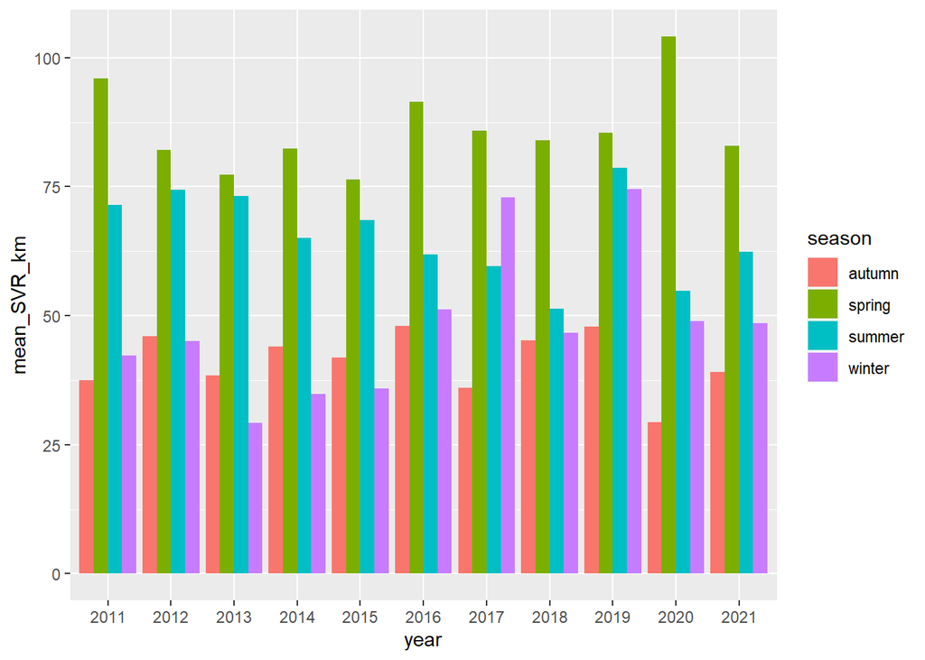

```r
mean_by_season%>%
  filter(SiteName=="Fresno")%>%
  ggplot(aes(year, mean_SVR_km, fill=season))+
  geom_col(position = "dodge")
```

Here is the shiny app:

```r
ui <- dashboardPage(
  dashboardHeader(title="Seasonal Metrics"),
  dashboardSidebar(disable = T),
  dashboardBody(

    tags$head(
      tags$style(HTML(".box{border-radius: 20px; box-shadow: 5px 5px 10px #888888;}"))),

    fluidRow(
      class="text center",
      box(
        selectInput("site", "Select Site Name", choices = unique(visibility_tidy_mdy$SiteName))
        ),
      box(
        selectInput("y", "Visibility Metric",
              choices = c("Standard Visual Range"="mean_SVR_km", "Ammonium Sulfate" = "mean_ammSO4_ppb",
                          "Ammonium Nitrate" = "mean_ammNO3_ppb", "Elemental Cabon" = "mean_EC_ppb",
                          "Organic Mass Cabon" = "mean_OMC_ppb", "Dust" = "mean_SOIL_ppb"),
              selected = "mean_SVR_km")
      ),
      box(
         plotOutput("plot", width = "1400px", height = "400px"), width = 12
      )
    )
  )
)

server <- function(input, output, session) {
  session$onSessionEnded(stopApp)
  output$plot <- renderPlot({
    mean_by_season%>%
      filter(SiteName == input$site)%>%
      ggplot(aes_string("year", input$y, fill="season"))+
      scale_fill_manual(values=c("#EB7500", "#9BEB01", "#E6E500", "#00CCE6"))+
      geom_col(position = "dodge", color="black")+
      theme(axis.title = element_text(size = 16),
            legend.text = element_text(size = 14),
            legend.title = element_text(size = 16),
            legend.background = element_rect(fill = "#F1F1F1"))+
      labs(x="Year",
           y=paste(str_split_1(input$y, "_")[2], str_split_1(input$y, "_")[3], sep=" "),
           fill="Season")
  })
}

shinyApp(ui, server, options = list(launch.browser = TRUE))
```